# Applied Machine Learning: In-class Exercise 05-1

## Goal

Our goal for this exercise sheet is to assess if a model is well-calibrated and calibrate it using calibration methods. We will do this using a train-validate-test split: the model is first fitted on training data and then calibrated on validation data. Test data will be used to compare the performance of the uncalibrated and calibrated models. Later, we will explore how to construct more refined resampling workflows for calibration.

## Required packages

We will use `scikit-learn` for machine learning:

```python
import numpy as np
import pandas as pd

from sklearn.model_selection import train_test_split

rng = np.random.default_rng(123)

# Unlike R, we cannot load the `cells` dataset from the library.
# So we provide the data along with the exercise sheet.

# To the students: please adjust the path to the csv file accordingly.
cells = pd.read_csv("../data/cells.csv")

# Remove the unwanted 'case' column if it exists.
if 'case' in cells.columns:
    cells = cells.drop(columns=['case'])
```

## 1 Checking cardinality properties

### 1.1 Creating a split with scikit-learn

Let’s use the `train_test_split()` function from scikit-learn to create a train-test-validation split. We will split the data twice: First, create a train-test split, and then split the training data again into training and validation datasets.

Perform the splits as follows:

First, create a train-test split with 60% of the data assigned to training and validation, and 40% to testing. Use stratification based on the class column to preserve class proportions. Next, split the resulting training set into training (70%) and validation (30%) datasets, again stratified by the class variable. Finally, separate each resulting dataset into predictors (`X`) and the outcome variable (`y`).

Check the shapes of the datasets to confirm the splits:

```python
#===SOLUTION===

cells_train_val, cells_test = train_test_split(
    cells,
    train_size=0.6,
    stratify=cells['class'],
    random_state=123
)

cells_train, cells_val = train_test_split(
    cells_train_val,
    train_size=0.7,
    stratify=cells_train_val['class'],
    random_state=123
)

X_train = cells_train.drop(columns=['class'])
y_train = cells_train['class']

X_val = cells_val.drop(columns=['class'])
y_val = cells_val['class']

X_test = cells_test.drop(columns=['class'])
y_test = cells_test['class']

print(f"Training set shape: X: {X_train.shape}, y: {y_train.shape}")
print(f"Validation set shape: X: {X_val.shape}, y: {y_val.shape}")
print(f"Test set shape: X: {X_test.shape}, y: {y_test.shape}")
```

```
Training set shape: X: (847, 56), y: (847,)
Validation set shape: X: (364, 56), y: (364,)
Test set shape: X: (808, 56), y: (808,)
```

### 1.2 Training a Naive Bayes model

We’ll illustrate the utility of calibration tools by using a type of model that, in this instance, is likely to produce a poorly calibrated outcome. The Naive Bayes classifier is a well-established algorithm that assumes predictors are statistically independent (to simplify computations). While this assumption does not hold true for our data, Naive Bayes can still effectively discriminate between classes. Unfortunately, when many predictors are included, this classifier tends to produce poorly calibrated probability distributions. Predicted probabilities frequently gravitate toward extremes (close to 0 or 1), resulting in a characteristic "U"-shaped distribution (Kuhn and Johnson, 2013).

To demonstrate, set up and train a Naive Bayes classifier using `sklearn.naive_bayes.GaussianNB` class. Use your training dataset (`X_train` and `y_train`) to fit the model.

```python
###===SOLUTION===

from sklearn.naive_bayes import GaussianNB

nb_model = GaussianNB()
nb_model.fit(X_train, y_train)
```

```
GaussianNB()
```

### 1.3 Predicting on unseen test data

Next, use the trained model to predict probabilities on unseen test data. In scikit-learn, calling `.predict_proba()` on the Naive Bayes model will return predicted probabilities for each class. Since this is a binary classification problem, you only need the predicted probabilities for class "PS" to evaluate model performance in the next step.

Perform the following steps:

Predict class probabilities using `.predict_proba()`. Identify the column corresponding to class "PS". Predict the class labels using `.predict()`. Create a DataFrame containing the actual class labels, predicted class labels, and the predicted probabilities for class "PS". Print out the head.

```python
#===SOLUTION===

# Get predicted probabilities for each class.
pred_probs = nb_model.predict_proba(X_test)

# Determine the index for class "PS".
ps_index = list(nb_model.classes_).index("PS")

# Get predicted classes
pred_class = nb_model.predict(X_test)

test_df_nb = pd.DataFrame({
    "class": y_test,
    "pred_class": pred_class,
    "pred_prob": pred_probs[:, ps_index]
})

test_df_nb.head()
```

|  | class | pred_class | pred_prob |
| --- | --- | --- | --- |
| 400 | PS | PS | 9.999873e-01 |
| 1389 | WS | PS | 8.673478e-01 |
| 1971 | WS | WS | 1.550348e-03 |
| 81 | PS | PS | 9.982106e-01 |
| 604 | PS | WS | 8.049752e-13 |

### 1.4 Assessing model performance

To evaluate how well the model performs, we will use two commonly used:

ROC AUC (Area Under the Receiver Operating Characteristic Curve) measures the model’s ability to correctly discriminate between the two classes.

Brier Score measures the accuracy of the predicted probabilities — that is, how close the predicted probabilities are to the actual outcomes. It reflects how well-calibrated the model is in expressing confidence in its predictions.

**Hint 1:**

To compute these metrics:

1. Convert the true labels to binary values: use 1 for the positive class "PS" and 0 for "WS".
2. Use `sklearn.metrics.roc_auc_score()` to compute the ROC AUC based on the predicted probabilities for class "PS".
3. Use `sklearn.metrics.brier_score_loss()` to compute the Brier score.

```python
#===SOLUTION===

from sklearn.metrics import roc_auc_score, brier_score_loss

# Map true labels to binary: 1 for "PS" (positive class) and 0 for "WS"
y_test_binary = (test_df_nb["class"] == "PS").astype(int)

# Compute ROC AUC using the predicted probability for class "PS"
roc_auc = roc_auc_score(y_test_binary, test_df_nb["pred_prob"])
print(f"ROC AUC: {roc_auc:.3f}")

# Compute the Brier score (Brier score loss)
brier = brier_score_loss(y_test_binary, test_df_nb["pred_prob"])
print(f"Brier Score: {brier:.3f}")
```

```
ROC AUC: 0.842
Brier Score: 0.188
```

### 1.5 Assessing model calibration

We provide the following function to simplify the visualization of calibration curves and to compute the Expected Calibration Error (ECE), a commonly used calibration metric. These plots divide the predicted probabilities into equally sized bins and compare the average predicted probability within each bin to the actual observed event rate. For example, if a bin captures predictions between 20% and 30%, a well-calibrated model would have roughly 25% of the samples in that bin belonging to the positive class. We will create calibration plots using both 10 and 5 bins to visually assess the model’s calibration. The objective is to evaluate how closely the predicted probabilities match the true class frequencies across bins. In our implementation, we rely on `sklearn.calibration.calibration_curve` and wrap it in a custom function to streamline the process.

```python
import matplotlib.pyplot as plt
from matplotlib.gridspec import GridSpec
from sklearn.calibration import CalibrationDisplay


def plot_calibration_curves(pred_df, y_binary, title_prefix="Uncalibrated"):
    """
    Plot histogram of predicted probabilities and calibration curves.

    Parameters:
    -----------
    pred_df : pandas.DataFrame
        DataFrame containing the predicted probabilities in column 'pred_prob'
    y_binary : array-like
        Binary target values (1 for positive class, 0 for negative class)
    title_prefix : str, default="Uncalibrated"
        Prefix for plot titles
    """
    # Create figure with GridSpec layout
    fig = plt.figure(figsize=(15, 5))
    gs = GridSpec(1, 3, figure=fig)

    # Main calibration curve plot
    ax_calibration = fig.add_subplot(gs[0, 0])

    # Use CalibrationDisplay for different bin sizes
    bin_sizes = [5, 10]
    colors = plt.get_cmap("Dark2")
    calibration_displays = {}

    for i, n_bins in enumerate(bin_sizes):
        # Calculate ECE manually
        bin_counts = np.histogram(pred_df["pred_prob"], bins=n_bins, range=(0, 1))[0]
        bin_boundaries = np.linspace(0, 1, n_bins + 1)
        ece = 0

        for j in range(n_bins):
            if bin_counts[j] > 0:
                # Get predictions in this bin
                bin_mask = (pred_df["pred_prob"] >= bin_boundaries[j]) & (pred_df["pred_prob"] < bin_boundaries[j + 1])
                if j == n_bins - 1:  # Include right boundary for last bin
                    bin_mask = (pred_df["pred_prob"] >= bin_boundaries[j]) & (pred_df["pred_prob"] <= bin_boundaries[j + 1])

                if bin_mask.sum() > 0:
                    bin_accuracy = y_binary[bin_mask].mean()
                    bin_confidence = pred_df["pred_prob"][bin_mask].mean()
                    ece += (bin_mask.sum() / len(y_binary)) * abs(bin_accuracy - bin_confidence)

        display = CalibrationDisplay.from_predictions(
            y_binary,
            pred_df["pred_prob"],
            n_bins=n_bins,
            name=f'{n_bins} bins (ECE: {ece:.3f})',
            ax=ax_calibration,
            color=colors(i)
        )
        calibration_displays[f'{n_bins} bins'] = display

    ax_calibration.grid(True, alpha=0.3)
    ax_calibration.set_title(f"{title_prefix} - Calibration Plot")
    ax_calibration.legend()

    # Individual histograms for each bin size
    for i, n_bins in enumerate(bin_sizes):
        ax = fig.add_subplot(gs[0, i + 1])

        display_name = f'{n_bins} bins'
        ax.hist(
            calibration_displays[display_name].y_prob,
            range=(0, 1),
            bins=10,
            label=display_name,
            color=colors(i),
            alpha=0.7,
            edgecolor='black'
        )
        ax.set_title(f"{display_name} - Probability Distribution")
        ax.set_xlabel("Mean predicted probability")
        ax.set_ylabel("Count")
        ax.grid(True, alpha=0.3)

    plt.tight_layout()
    plt.show()
```

Task: Call the function with the current predictions on the test set.

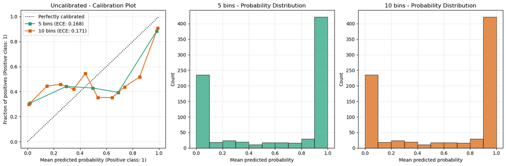

```python
#===SOLUTION===

plot_calibration_curves(test_df_nb, y_test_binary)
```

### 2 Platt Scaling

The good news is that we can improve the probability estimates. Several techniques exist to adjust the predicted probabilities so they better reflect the actual observed outcomes — in other words, to improve calibration. Different methods correct these estimates in different ways.

One of the most common approaches is Platt Scaling, also called logistic calibration. The process works as follows: the original model is used to make probability predictions on a validation dataset. These predicted probabilities, which are often poorly calibrated, are then used as input to a logistic regression model. The logistic regression learns to correct the systematic errors in the original model’s probabilities. Conceptually, this creates a stacked model:

`Original Model → Probabilities → Logistic Regression → Calibrated Probabilities`.

If successful, the logistic regression identifies regions where the original model tends to under- or over-predict. For example, if the model typically predicts around 2% probability for certain samples, but the observed frequency is actually 7%, the logistic model will learn to adjust those predictions upwards accordingly.

### 2.1 Platt Scaling with scikit-learn

#### 2.1.1 Task

Given the predicted probabilities from a Naive Bayes classifier on a validation dataset, build a calibration model by training a logistic regression model. This logistic regression model will act as a calibrator to improve the probability estimates from the Naive Bayes classifier.

**Hint 1:**

`sklearn.calibration.CalibratedClassifierCV` accepts a fitted learner as base learner and trains a calibrator model on the top.

**Hint 2:**

You can create a frozen copy for the Naive Bayes model using `sklearn.frozen.FrozenEstimator` to avoid re-fitting the model in `CalibratedClassifierCV`.

```python
#===SOLUTION===

from sklearn.calibration import CalibratedClassifierCV
from sklearn.frozen import FrozenEstimator

# Create a frozen version of the Naive Bayes model
nb_frozen = FrozenEstimator(nb_model)

# Create a calibrated classifier using Platt scaling (sigmoid method)
calibrator_platt = CalibratedClassifierCV(estimator=nb_frozen, method='sigmoid', cv=5)

# Fit the calibrator on the validation data
calibrator_platt.fit(X_val, y_val)
```

```
CalibratedClassifierCV(cv=5, estimator=FrozenEstimator(estimator=GaussianNB()))
```

### 2.1.2 Discussion

How do we know if the calibration actually worked? Since we used the training data to fit the Naive Bayes model and the validation data to fit the logistic regression (Platt scaling) model, we now need to assess the performance of the combined model on the test data.

**Hint 1:**

To evaluate calibration:

1. Call `calibrator_platt.predict_proba(X_test)` to get calibrated probabilities.
2. Compute ROC AUC and Brier score.
3. Plot and compare calibration curves for both uncalibrated and calibrated models.

This will show whether calibration improved probability estimates.

```
Calibrated model ROC AUC: 0.842
Calibrated model Brier Score: 0.161
```

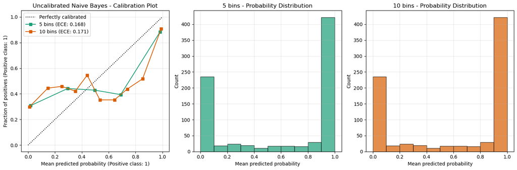

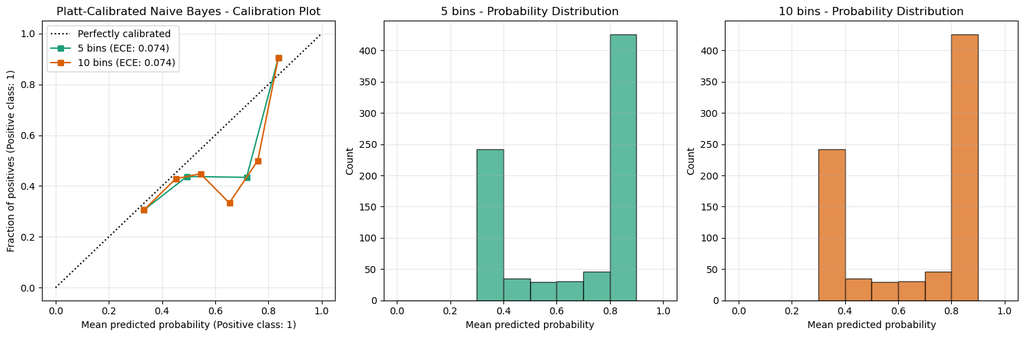

```python
#===SOLUTION===

# Get predicted probabilities on the test set using the uncalibrated model
pred_probs_test = nb_model.predict_proba(X_test)
ps_index = list(nb_model.classes_).index("PS")
pred_prob_test = pred_probs_test[:, ps_index]

# Apply the calibrator to the test set. Remember to use the correct class index
calibrated_probs_all = calibrator_platt.predict_proba(X_test)

# Find the correct index for "PS" class in the calibrated classifier
ps_index_calibrated = list(calibrator_platt.classes_).index("PS")
calibrated_probs = calibrated_probs_all[:, ps_index_calibrated]

# Create a DataFrame with the calibrated predictions
test_df_platt = pd.DataFrame({
    'class': y_test,
    'pred_class': np.where(calibrated_probs >= 0.5, "PS", "WS"),
    'pred_prob': calibrated_probs
})

# Convert true labels to binary: 1 for "PS", 0 for "WS"
y_test_binary = (y_test == "PS").astype(int)

# Compute ROC AUC and Brier score for the calibrated model
roc_auc_calibrated = roc_auc_score(y_test_binary, test_df_platt["pred_prob"])
brier_calibrated = brier_score_loss(y_test_binary, test_df_platt["pred_prob"])

print(f"Calibrated model ROC AUC: {roc_auc_calibrated:.3f}")
print(f"Calibrated model Brier Score: {brier_calibrated:.3f}")

# Plot calibration curves for both uncalibrated and calibrated models
plot_calibration_curves(test_df_nb, y_test_binary, title_prefix="Uncalibrated Naive Bayes")
plot_calibration_curves(test_df_platt, y_test_binary, title_prefix="Platt-Calibrated Naive Bayes")
```

Discuss your observations from the ROC AUC, Brier Score and the calibration curves.

===SOLUTION===

We observe a modest improvement after calibration. The Brier score, evaluated on the test data, has improved, indicating that the calibrated probabilities are now closer to the true outcomes. Interestingly, the ROC AUC remains unchanged. This is expected, as the ROC AUC measures the model's ability to discriminate between classes. Since Platt scaling only adjusts the predicted probabilities (without altering the ranking of predictions), it typically has little to no effect on the ROC AUC. The calibration curves also show noticeable improvement.

The curves of the calibrated model align more closely with the diagonal, indicating better agreement between predicted probabilities and observed event rates. Additionally, the ECE has decreased, further confirming that the calibration procedure improved the reliability of the model's probability estimates.

## 3 Isotonic regression

A different approach to calibration is to use isotonic regression. In a manner similar to logistic calibration, use probably to calibrate the Naive Bayes model using isotonic regression. Do we improve the calibration in comparison to Platt scaling?

Use `CalibratedClassifierCV(method='isotonic')` to calibrate the predictions with isotonic regression. Compute the ROC AUC and Brier Score. In addition, plot the calibration curve for the uncalibrated model, Platt scaling-calibrated model, Isotonic regression-calibrated model. Disscuss your observations.

```
Isotonic calibrated ROC AUC: 0.836
Isotonic calibrated Brier Score: 0.158
```

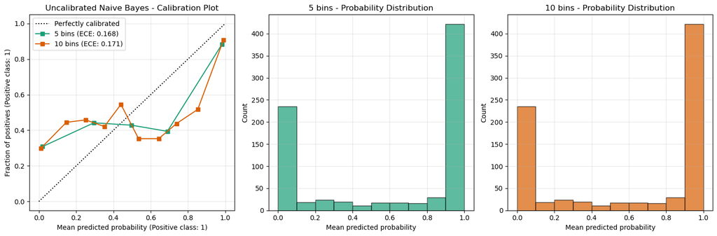

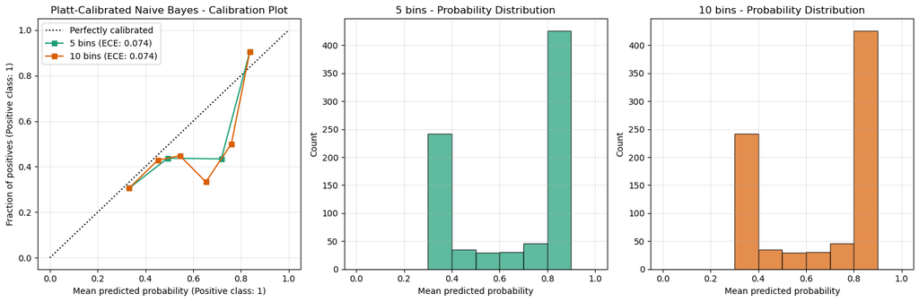

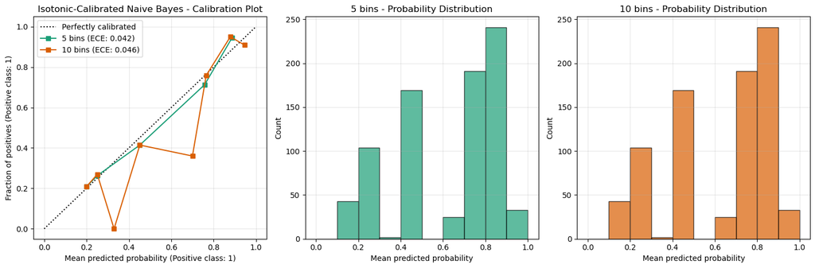

```python
#===SOLUTION===

# 1. Create and fit the isotonic regression calibrator using CalibratedClassifierCV
nb_frozen = FrozenEstimator(nb_model)
# Create a calibrated classifier using isotonic regression
calibrator_iso = CalibratedClassifierCV(estimator=nb_frozen, method='isotonic', cv=5)

# Fit the calibrator on the validation data
calibrator_iso.fit(X_val, y_val)

# 2. Apply the isotonic regression calibrator to the test set predictions
# Apply the calibrator to the test set - Use correct class index
iso_probs_all = calibrator_iso.predict_proba(X_test)

# Find the correct index for "PS" class in the calibrated classifier
ps_index_iso = list(calibrator_iso.classes_).index("PS")
iso_pred_prob = iso_probs_all[:, ps_index_iso]

# Create a new DataFrame for the isotonic calibrated test predictions
test_df_iso = pd.DataFrame({
    'class': y_test,
    'pred_class': np.where(iso_pred_prob >= 0.5, "PS", "WS"),
    'pred_prob': iso_pred_prob
})

# 3. Evaluate performance of the isotonic calibrated model
# Convert true labels to binary: 1 for "PS", 0 for "WS"
y_test_binary = (y_test == "PS").astype(int)

roc_auc_iso = roc_auc_score(y_test_binary, test_df_iso["pred_prob"])
brier_iso = brier_score_loss(y_test_binary, test_df_iso["pred_prob"])

print(f"Isotonic calibrated ROC AUC: {roc_auc_iso:.3f}")
print(f"Isotonic calibrated Brier Score: {brier_iso:.3f}")

# 4. Plot calibration curves using the existing function
# Plot calibration curves for both uncalibrated and calibrated models
plot_calibration_curves(test_df_nb, y_test_binary, title_prefix="Uncalibrated Naive Bayes")
plot_calibration_curves(test_df_platt, y_test_binary, title_prefix="Platt-Calibrated Naive Bayes")
plot_calibration_curves(test_df_iso, y_test_binary, title_prefix="Isotonic-Calibrated Naive Bayes")
```

===SOLUTION===

It seems that Isotonic Regression can further improve the performance compared to Platt Scaling. Note that this observation is different from the R version.

## 4 Resampling for Calibration

So far, we've used a simple train-validation-test split to calibrate and evaluate our models. However, in practice, we often prefer using resampling techniques, such as cross-validation, to more robustly estimate model calibration performance.

In this section, we apply 10-fold cross-validation to fit and calibrate Naive Bayes models. Rather than using Platt scaling, we will demonstrate an alternative method: **beta calibration**. This is a more flexible, non-linear calibration technique based on a logistic-like transformation of predicted probabilities.

`scikit-learn` does not provide function of beta calibration. Here, we provide an implementation of beta calibration following Algorithm 1 from Kull et al. (2017).

**Hint 1:**

You can conduct the CV with beta calibration as follows.

For each CV fold:

1. Train the base model: Fit a Naive Bayes classifier on the training fold using `nb_model.fit()`.
2. Predict uncalibrated probabilities: Use `nb_model.predict_proba()` on the validation fold to obtain uncalibrated probabilities. Then, extract the probabilities for the "PS" class.
3. Fit the beta calibration model: Call `fit_beta_calibration(predictions, true_labels)` to estimate the calibration parameters (`a` and `c` in Algorithm 1 of Kull et al. 2017) based on the uncalibrated probabilities and the true labels of the validation fold.
4. Apply beta calibration: Use `beta_calibration_predict(predictions, params)` to obtain calibrated probabilities for the validation fold.
5. Evaluate both models: Compute the ROC AUC and Brier Score for both the uncalibrated and beta-calibrated probabilities.

After completing all folds, aggregate the results to compare the average ROC AUC, brier score. You can also visualize the calibration curves.

```python
from sklearn.model_selection import StratifiedKFold
from scipy.optimize import minimize


# Implementation of Algorithm 1 from https://proceedings.mlr.press/v54/kull17a.html

def beta_calibration_loss(params, p, y):
    """Negative log-likelihood for beta calibration.

    Parameters:
      params: array-like, [a, c]
      p: uncalibrated probabilities (predicted for positive class)
      y: true binary labels (1 for "PS", 0 for "WS")
    """
    a, c = params
    # Avoid log(0) issues by clipping
    p = np.clip(p, 1e-15, 1 - 1e-15)
    log_term = a * np.log(p / (1 - p)) + c
    q = 1 / (1 + np.exp(-log_term))  # Corrected sign
    loss = -np.sum(y * np.log(q) + (1 - y) * np.log(1 - q))
    return loss

def fit_beta_calibration(p, y):
    """Fit beta calibration parameters.

    Returns optimal parameters (a, c) estimated via minimization.
    """
    initial_guess = np.array([1.0, 0.0])
    result = minimize(beta_calibration_loss, initial_guess, args=(p, y), method='L-BFGS-B')
    return result.x

def beta_calibration_predict(p, params):
    """Apply beta calibration using parameters from fit_beta_calibration.

    Returns calibrated probabilities.
    """
    a, c = params
    p = np.clip(p, 1e-15, 1 - 1e-15)
    log_term = a * np.log(p / (1 - p)) + c
    q = 1 / (1 + np.exp(-log_term))
    return q
```

```
Uncalibrated model: Average ROC AUC: 0.808; Brier Score: 0.209
Beta calibrated model: Average ROC AUC: 0.808; Brier Score: 0.204
```

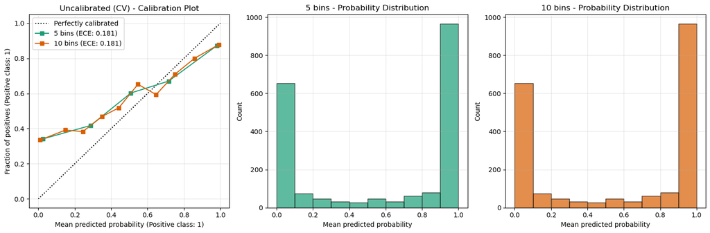

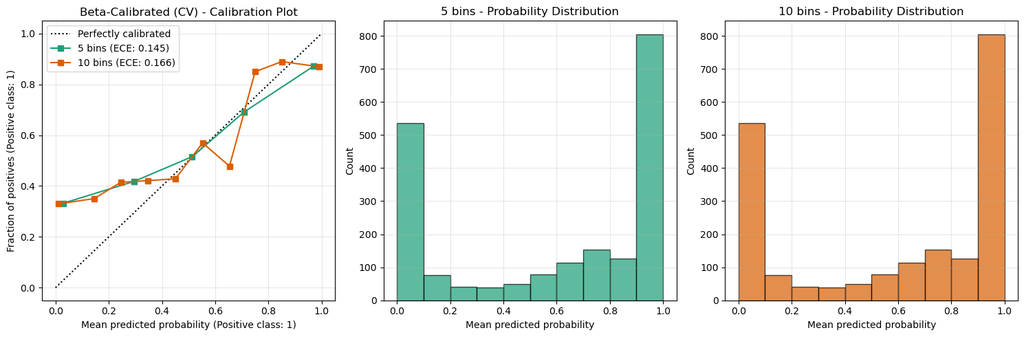

```python
#===SOLUTION===

# 10-fold CV with beta calibration
skf = StratifiedKFold(n_splits=10, shuffle=True, random_state=123)

uncalibrated_roc_auc = []
uncalibrated_brier = []
beta_roc_auc = []
beta_brier = []
all_true = []
all_uncal_pred = []
all_beta_pred = []

for train_idx, val_idx in skf.split(cells, cells['class']):
    train_fold = cells.iloc[train_idx]
    val_fold = cells.iloc[val_idx]

    X_train_fold = train_fold.drop(columns=['class'])
    y_train_fold = train_fold['class']
    X_val_fold = val_fold.drop(columns=['class'])
    y_val_fold = val_fold['class']

    # Fit Naive Bayes on training fold.
    nb_model = GaussianNB()
    nb_model.fit(X_train_fold, y_train_fold)

    # Predict probabilities on the validation fold.
    prob_val = nb_model.predict_proba(X_val_fold)
    ps_index = list(nb_model.classes_).index("PS")
    uncal_pred = prob_val[:, ps_index]

    # Convert true labels to binary: 1 for "PS", 0 for "WS"
    y_val_bin = (y_val_fold == "PS").astype(int).values

    # Fit beta calibration using our custom function.
    params = fit_beta_calibration(uncal_pred, y_val_bin)
    beta_pred = beta_calibration_predict(uncal_pred, params)

    # Compute metrics for uncalibrated predictions.
    roc_uncal = roc_auc_score(y_val_bin, uncal_pred)
    brier_uncal = brier_score_loss(y_val_bin, uncal_pred)
    # And for beta calibrated predictions.
    roc_beta = roc_auc_score(y_val_bin, beta_pred)
    brier_beta = brier_score_loss(y_val_bin, beta_pred)

    uncalibrated_roc_auc.append(roc_uncal)
    uncalibrated_brier.append(brier_uncal)
    beta_roc_auc.append(roc_beta)
    beta_brier.append(brier_beta)

    # Store for calibration plot.
    all_true.extend(y_val_bin)
    all_uncal_pred.extend(uncal_pred)
    all_beta_pred.extend(beta_pred)

print(f"Uncalibrated model: Average ROC AUC: {np.mean(uncalibrated_roc_auc):.3f}; Brier Score: {np.mean(uncalibrated_brier):.3f}")
print(f"Beta calibrated model: Average ROC AUC: {np.mean(beta_roc_auc):.3f}; Brier Score: {np.mean(beta_brier):.3f}")

uncal_df = pd.DataFrame({
    'class': ['PS' if y == 1 else 'WS' for y in all_true],
    'pred_prob': all_uncal_pred,
    'pred_class': ['PS' if p >= 0.5 else 'WS' for p in all_uncal_pred]
})

beta_df = pd.DataFrame({
    'class': ['PS' if y == 1 else 'WS' for y in all_true],
    'pred_prob': all_beta_pred,
    'pred_class': ['PS' if p >= 0.5 else 'WS' for p in all_beta_pred]
})

# Convert true labels to binary for plotting
y_true_binary = np.array(all_true)

# Plot calibration curves using the existing function
plot_calibration_curves(uncal_df, y_true_binary, title_prefix="Uncalibrated (CV)")
plot_calibration_curves(beta_df, y_true_binary, title_prefix="Beta-Calibrated (CV)")
```

## Summary

In this exercise sheet, we learned how to fit a classification model using `scikit-learn` and how to assess its performance on unseen test data. We demonstrated how to manually split the data into training, validation, and test sets, and how to assess model calibration.

We explored how to diagnose poor calibration using calibration plots and metrics such as the Brier Score. We then applied Platt scaling (logistic calibration) and Isotonic Regression as techniques to improve the calibration of predicted probabilities.

It is also worth noting that in a real-world scenario, once the calibrator is fitted, we would typically retrain the Naive Bayes classifier on the combined training and validation data before applying it to the test data. This mirrors the logic of nested resampling and helps to reduce bias in performance estimation.

This tutorial is a Python adaptation of the original tidymodels introduction to calibration, used under a CC BY-SA license.